# Reproducible Research: Peer Assessment 1

## Loading and preprocessing the data. Also loading dplyr to work easier.

```r
library(dplyr)
Data <- read.csv(unz("activity.zip", "activity.csv"), header = T)
```

## What is mean total number of steps taken per day?

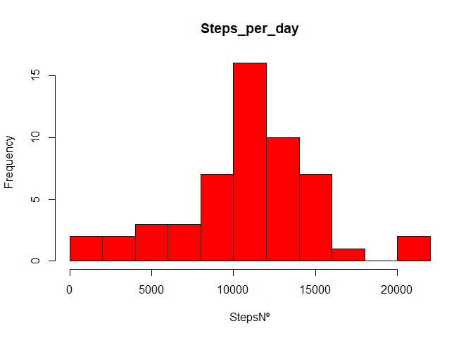

```r
SPD <- Data %>%
  group_by(date) %>%
  summarise(Steps_per_day = sum(steps))

hist(SPD$Steps_per_day, main="Steps_per_day", xlab="StepsNº", col="red", breaks=10)
```

```r
meanSteps_per_day <- mean(SPD$Steps_per_day, na.rm = T)
medianSteps_per_day <- median(SPD$Steps_per_day, na.rm = T)
```

The mean is 1.0766189^{4} and the median is 10765.

## What is the average daily activity pattern?

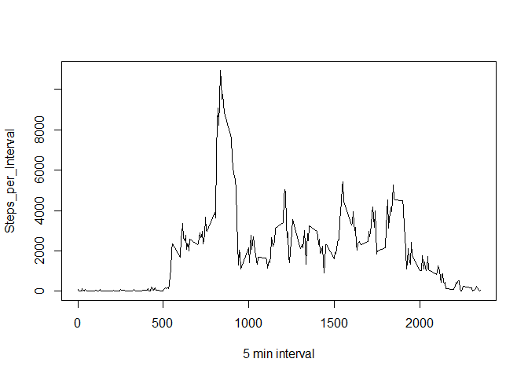

```r
SPI <- Data %>%
  group_by(interval) %>%
  summarise(Steps_per_Interval = sum(steps, na.rm = T))

plot(SPI$interval,SPI$Steps_per_Interval, type="l", xlab = "5 min interval", ylab = "Steps_per_Interval")
```

```r
MaxStepsInt<-SPI$interval[which.max(SPI$Steps_per_Interval)]
```

The interval with more steps averaged across all days is 835.

## Imputing missing values

```r
NAnumber<-sum(is.na(Data))
```

The number of missing data is 2304.

The strategy selected for imputing missing values is making the average for the 5-minute interval across all days.We calculate it, create a new column with the average per interval and join it with the original data table, keepeng the averaged value when we don’t have any.

```r
ASPI <- Data %>%
  group_by(interval) %>%
  summarise(Aver_Steps_per_Interval = mean(steps, na.rm = T))

Data2 <- full_join(Data, ASPI, by="interval") %>%
  mutate(steps=case_when(is.na(steps)~as.integer(Aver_Steps_per_Interval), TRUE ~ steps)) %>%
  select(steps,date,interval)
```

Finally we calculate the number of steps taken, make the histogram and calculate mean and median.

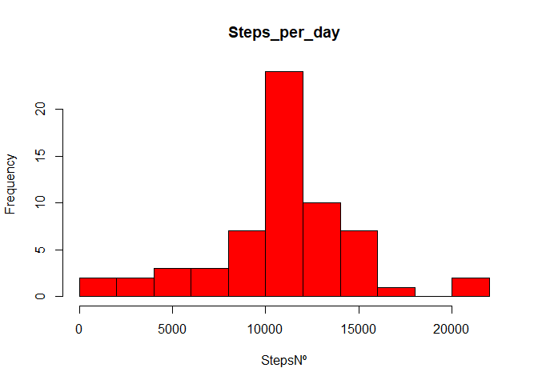

```r
SPD2 <- Data2 %>%
  group_by(date) %>%
  summarise(Steps_per_day = sum(steps))

hist(SPD2$Steps_per_day, main="Steps_per_day", xlab="StepsNº", col="red", breaks=10)
```

```r
meanImp_Steps_per_day <- mean(SPD2$Steps_per_day, na.rm = T)
medianImp_Steps_per_day <- median(SPD2$Steps_per_day, na.rm = T)
```

The new mean is 1.074977^{4}. The new median is 10641.

Comparing it to the unmodified data, we see that the most frequent break (10,000-12,000) has increased in frequency. That is due to using the average of steps per interval to replace NA.

## Are there differences in activity patterns between weekdays and weekends?

We load the library timeDate to make te separation between weekends and weekdays easier.

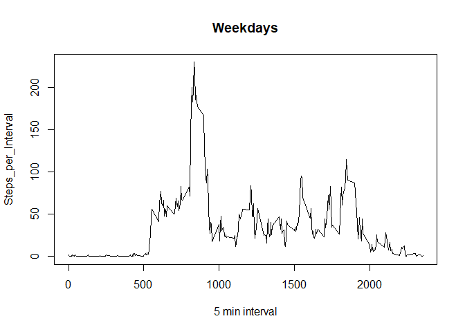

```r
library(timeDate)
WeeklyData <- Data2 %>%
  mutate(
    dayType=case_when(
      isWeekend(as.Date(Data2$date))~"weekend",TRUE~"weekday"))

WeeklyData$dayType<-as.factor(WeeklyData$dayType)

Weekdays<-WeeklyData %>%
  filter(dayType=="weekday") %>%
  group_by(interval) %>%
  summarise(Steps_per_Interval = mean(steps, na.rm = T))

Weekends<-WeeklyData %>%
  filter(dayType=="weekend") %>%
  group_by(interval) %>%
  summarise(Steps_per_Interval = mean(steps, na.rm = T))

plot(Weekdays$interval,
     Weekdays$Steps_per_Interval,
     type="l",
     xlab = "5 min interval",
     ylab = "Steps_per_Interval",
     main = "Weekdays")
```

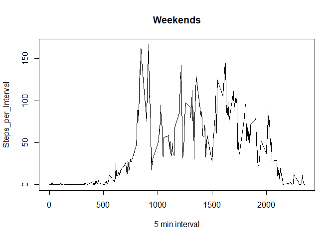

```r
plot(Weekends$interval,
     Weekends$Steps_per_Interval,
     type="l",
     xlab = "5 min interval",
     ylab = "Steps_per_Interval",
     main="Weekends")
```